# New blending procedure

**TL;DR: the blending procedure translated to py performs well enough compared to the original NCL one.**

There are also good reasons to recalculate:

- make things technically consistent and exatcly reproducible, it is "more correct"
- Launching recalculation probably takes less time than writing this list of pros and cons!

I have tested the last 2 years of monthly updates for different SPI periods. Subtracting the new procedure output with the existing data then looking at deltas. Below they are aggregated, since no relevant difference are found among periods or months.

```
## [1] "within +/- 0.5"
##    Min. 1st Qu.  Median    Mean 3rd Qu.    Max.
##  0.9934  0.9984  0.9991  0.9988  0.9995  0.9999
## [1] "within +/- 0.1"
##    Min. 1st Qu.  Median    Mean 3rd Qu.    Max.
##  0.9763  0.9880  0.9901  0.9896  0.9913  0.9952
## [1] "within +/- 0.01"
##    Min. 1st Qu.  Median    Mean 3rd Qu.    Max.
##  0.9548  0.9718  0.9764  0.9746  0.9788  0.9841
```

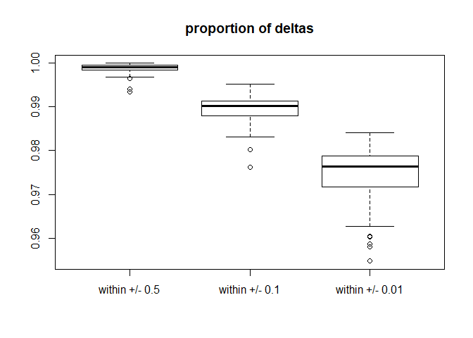

The summary shows that the vast majority of values (about 97%) falls within plus minus 0.01 compared to old NCL version).

I did investigate the outlier date that seem to perform worse, see below.

### What about extreme SPI values?

**The new procedure smoothes slightly more the extremes** Below I removed all SPI between +/- 1 and fitted a linear model of original vs new data for the worst performing date tested (2019-05-01). The model ideally should return y = x. The actual model correctly has intercept close to zero and slope close to 1:

```
##
## Call:
## lm(formula = getValues(frr) ~ getValues(fr))
##
## Coefficients:
##   (Intercept)  getValues(fr)
##     -0.001757       0.997809
```

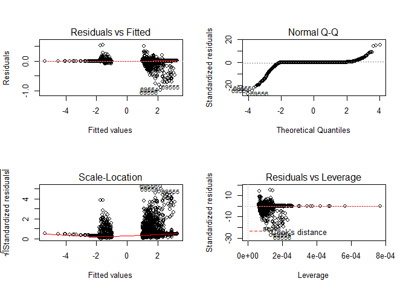

Residuals show some pattern (upper left), but for a small num of records overall. qq plot shows heavy tails (upper right): the more extreme, the more departure from zero difference. However these values are more and more rare departing from zero, by definition. Also in a classified map they won't show such differences. Data seems slightly heteroskedastic (lower left), but just because of not many values at extremes and a slight non linearity is detected. Basically no outliers are detected (lower right), nor any influences the model (i.e. the previous are reliable).

Modelling the differences (not shown) shows very small slope, not equal to zero as it should but close, and negligible given the limited range of values SPI take. also intercept is very close to zero, as it should.

```
##
## Call:
## lm(formula = md ~ mfr)
##
## Residuals:
##      Min       1Q   Median       3Q      Max
## -0.53829 -0.00512 -0.00413  0.00116  0.97548
##
## Coefficients:
##              Estimate Std. Error t value Pr(>|t|)
## (Intercept) 0.0017572  0.0002680   6.557 5.65e-11 ***
## mfr         0.0021906  0.0001683  13.014  < 2e-16 ***
## ---
## Signif. codes:  0 '***' 0.001 '**' 0.01 '*' 0.05 '.' 0.1 ' ' 1
##
## Residual standard error: 0.0357 on 18364 degrees of freedom
##   (77106 observations deleted due to missingness)
## Multiple R-squared:  0.009138,   Adjusted R-squared:  0.009084
## F-statistic: 169.4 on 1 and 18364 DF,  p-value: < 2.2e-16
```

### map of deltas

The map shows standard deviation and average of all deltas, aggregated regardless periods and months. You can see that at the boundary of the search radius of the blending algorithms there are the wider differences. It is difficult to track back the source of difference, because I cannot find the original code for a key function.

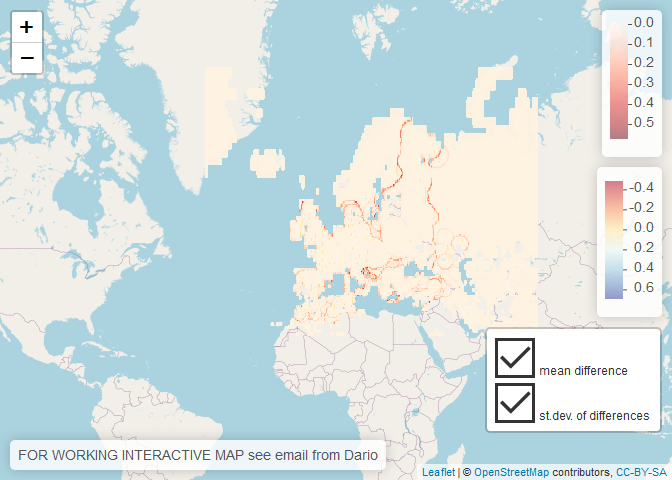

## summary month by month

Number of cells with values of **difference** (not SPI value) beyond +/- 1. Summary and boxplot below refer to the full sample of 120 months/SPI combos

```
##    Min. 1st Qu.  Median    Mean 3rd Qu.    Max.
##   0.000   2.000   4.000   5.642   8.250  20.000
```

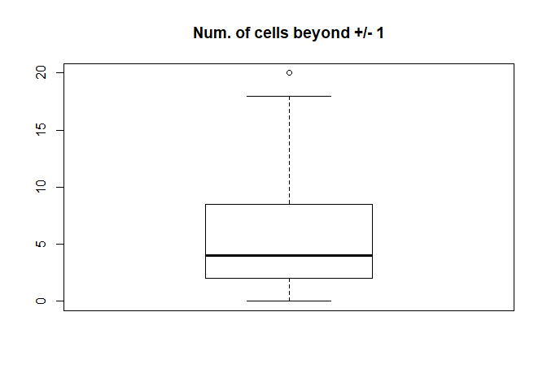

Below follows month by month analysis with proportion of cells within 3 tolerance levels (ignore missing values), number of cells beyond +/- 1 and the summary of all cells for a month

```
## [1] "Month: 2018 04  -- SPI 01"
## [1] "difference within +/- 0.5 0.999"
## [1] "difference within +/- 0.1 0.989"
## [1] "difference within +/- 0.01 0.972"
## [1] "Num. of cells with difference beyond +/- 1 ->  2 out of  57760"
##    Min. 1st Qu.  Median    Mean 3rd Qu.    Max.    NA's
##   -1.93    0.00    0.00    0.00    0.00    0.93   37712
## [1] "------------"
## [1] "Month: 2018 05  -- SPI 03"
## [1] "difference within +/- 0.5 0.999"
## [1] "difference within +/- 0.1 0.988"
## [1] "difference within +/- 0.01 0.97"
## [1] "Num. of cells with difference beyond +/- 1 ->  2 out of  58368"
##    Min. 1st Qu.  Median    Mean 3rd Qu.    Max.    NA's
##   -0.85    0.00    0.00    0.00    0.00    1.09   37104
```

[output cut: 945 more lines]